# Regressão linear

Probest

fnaufel

(v. 17/09/2021)

# 1 Exemplo: altura e peso

Pessoas mais altas tendem a ser mais pesadas?

Temos dados de $68$ pessoas, com alturas em cm e pesos em kg:

| altura | peso |
| --- | --- |
| 162,56 | 49,50 |
| 160,02 | 55,35 |
| 180,34 | 60,30 |
| 162,56 | 58,05 |
| 157,48 | 58,05 |
| 165,10 | 55,35 |
| 163,83 | 51,75 |
| 173,99 | 54,90 |
| 166,37 | 54,00 |
| 162,56 | 49,95 |

[output cut: 58 more lines]

- O gráfico de dispersão (*scatterplot*) é o ideal para visualizar a correlação entre duas variáveis numéricas:

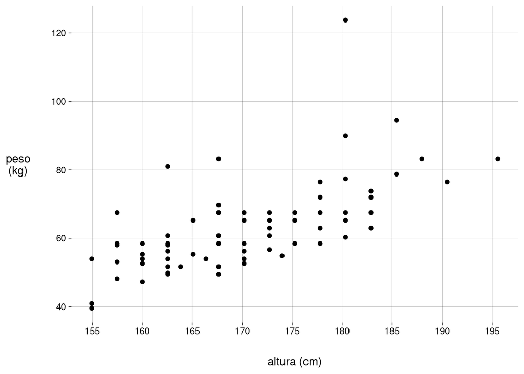

  ```r
  grafico_pa <- peso_altura %>%
    ggplot(aes(altura, peso)) +
      geom_point() +
      labs(
        x = 'altura (cm)',
        y = 'peso\n(kg)'
      ) +
      scale_x_continuous(breaks = seq(150, 200, 5))

  grafico_pa
  ```

- Podemos pedir ao R para traçar uma reta resumindo a variação do peso em função da altura:

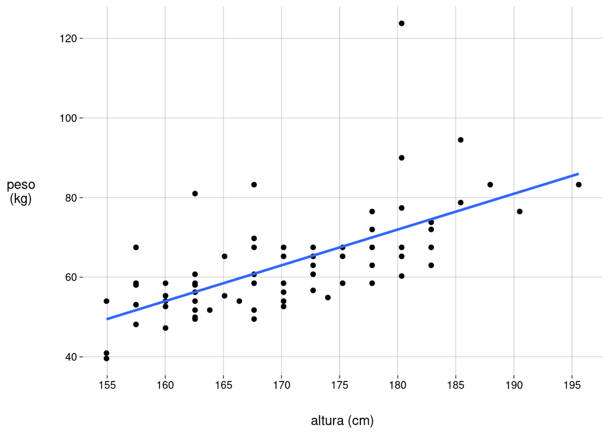

  ```r
  regressao <- grafico_pa +
    geom_smooth(method = 'lm', formula = y ~ x, se = FALSE)

  regressao
  ```

- Esta é a reta de regressão, ou reta de melhor ajuste.
- Se tivermos a equação desta reta, podemos
  1. Explicar como o peso varia de acordo com a altura.
  2. Prever o peso de pessoas cujas alturas não estavam nos dados originais.
- A equação da reta vai ser da forma $\quad$ $\widehat{\text{peso}}(x) = \widehat{b_0} + \widehat{b_1} \cdot \text{altura}(x)$.
- Os “chapéus” em $\widehat{\text{peso}}$, $\widehat{b_0}$, e em $\widehat{b_1}$ significam que os valores são estimativas, e não valores exatos.
- Neste exemplo, a equação da reta é $\quad$ $\widehat{\text{peso}}(x) = -89{,}81 + 0{,}90 \cdot \text{altura}(x)$.
- Dando nomes às coisas:
  - O intercepto é o valor de $\widehat{b_0} = -89{,}81$. Neste exemplo, corresponderia ao peso de uma pessoa com altura zero! Claro que isto não faz sentido na realidade física, mas é um valor que faz parte da definição da reta. Aliás, serve como aviso de que a reta de regressão só faz sentido dentro da faixa de valores dos dados que temos.
  - A inclinação é o valor de $\widehat{b_1} = 0{,}90$. Neste exemplo, significa que um aumento de $1$cm na altura corresponde a um aumento de $0{,}90$kg no peso.
  - O resíduo de um indivíduo $x$ do conjunto de dados é a diferença entre o peso verdadeiro de $x$ e o peso estimado para $x$ pela equação.

    Por exemplo, para as duas pessoas com altura próxima a $1{,}65$m:

# 2 Como achar a equação da melhor reta? Com Cálculo!

- Qual reta queremos? A que deixe o mínimo possível de resíduos.
- Mas, em vez de considerar os resíduos, que podem ser negativos ou positivos, vamos considerar os quadrados dos resíduos, mais ou menos como no cálculo da variância.
- Então, para cada indivíduo $x_i$, calculamos o resíduo e elevamos ao quadrado; depois, somamos tudo:

  $$S = \sum_i \left[\text{peso}(x_i) - \widehat{\text{peso}}(x_i)\right]^2$$
- Esta soma $S$ é a quantidade que queremos minimizar: a soma dos quadrados dos resíduos.
- Exemplos de retas diferentes, com seus valores de S:

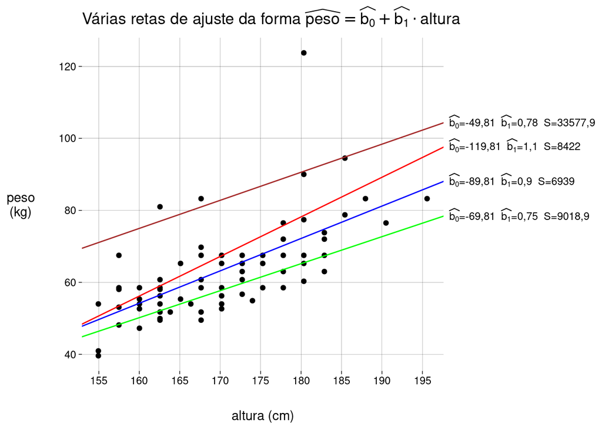

- Mas lembre-se de que $\widehat{peso}(x_i) = \widehat{b_0} + \widehat{b_1} \cdot \text{altura}(x_i)$.
- Então, a soma fica

  $$S = \sum_i \left[\;\text{peso}(x_i) - (\widehat{b_0} + \widehat{b_1} \cdot \text{altura}(x_i))\;\right]^2$$
- No fim das contas, $S$ é uma função de duas variáveis: $\widehat{b_0}$ e $\widehat{b_1}$ (lembre-se de que os pesos e alturas das pessoas são conhecidos).
- Podemos usar as ferramentas do Cálculo para achar os valores de $\widehat{b_0}$ e $\widehat{b_1}$ que minimizam esta função.
- Vamos um passo de cada vez.

  Para lembrarmos que $S$ é uma função de $\widehat{b_0}$ e $\widehat{b_1}$, vamos escrever $S\left(\widehat{b_0}, \widehat{b_1}\right)$:

  $$\begin{align*}
  S\left(\widehat{b_0}, \widehat{b_1}\right) &=
  \sum_i
  \left[\;y_i -
  (\widehat{b_0} +
  \widehat{b_1} x_i)
  \;\right]^2
  \end{align*}$$
- Desenvolvendo o quadrado:

  $$\begin{align*}
  S\left(\widehat{b_0}, \widehat{b_1}\right) &=
  \sum_i
  \left[\;
  y_i^2 -
  2y_i(\widehat{b_0} + \widehat{b_1}x_i)
  + (\widehat{b_0} + \widehat{b_1}x_i)^2
  \;\right]
  \end{align*}$$
- Desenvolvendo o quadrado no final:

  $$\begin{align*}
  S\left(\widehat{b_0}, \widehat{b_1}\right) &=
  \sum_i
  \left[\;
  y_i^2 -
  2y_i(\widehat{b_0} + \widehat{b_1}x_i)
  + \widehat{b_0}^2 +
  2\widehat{b_0}\widehat{b_1}x_i +
  \widehat{b_1}^2x_i^2
  \;\right]
  \end{align*}$$
- Desenvolvendo a parte com parênteses:

  $$\begin{align*}
  S\left(\widehat{b_0}, \widehat{b_1}\right) &=
  \sum_i
  \left[\;
  y_i^2 -
  2y_i\widehat{b_0} -
  2y_i\widehat{b_1}x_i +
  \widehat{b_0}^2 +
  2\widehat{b_0}\widehat{b_1}x_i +
  \widehat{b_1}^2x_i^2
  \;\right]
  \end{align*}$$
- Separando os somatórios:

  $$\begin{align*}
  S\left(\widehat{b_0}, \widehat{b_1}\right) &=
  \sum_i y_i^2 -
  \sum_i 2y_i\widehat{b_0} -
  \sum_i 2y_i\widehat{b_1}x_i +
  \sum_i \widehat{b_0}^2 +
  \sum_i 2\widehat{b_0}\widehat{b_1}x_i +
  \sum_i \widehat{b_1}^2x_i^2
  \end{align*}$$
- Jogando tudo que não depende de $i$ para fora dos somatórios.

  Além disso, $\sum_i \widehat{b_0}^2$ é simplesmente $n\widehat{b_0}^2$, onde $n$ é o total de pessoas.

  $$\begin{align*}
  S\left(\widehat{b_0}, \widehat{b_1}\right) &=
  \sum_i y_i^2 -
  2\widehat{b_0}\sum_i y_i -
  2\widehat{b_1}\sum_i x_iy_i +
  n\widehat{b_0}^2 +
  2\widehat{b_0}\widehat{b_1}\sum_i x_i +
  \widehat{b_1}^2\sum_i x_i^2
  \end{align*}$$
- Pronto. Agora vamos achar as derivadas parciais desta função:

  $$\begin{align*}
  \frac{\partial S}{\partial \widehat{b_0}} &=
  -2\sum_i y_i + 2n\widehat{b_0} + 2\widehat{b_1}\sum_i x_i \\
  \\
  \frac{\partial S}{\partial \widehat{b_1}} &=
  -2\sum_i x_i y_i + 2\widehat{b_0}\sum_i x_i + 2\widehat{b_1}\sum_i x_i^2
  \end{align*}$$
- Os valores de $\widehat{b_0}$ e $\widehat{b_1}$ para os quais estas duas derivadas são iguais a zero são os valores que estamos procurando.
- Para $\frac{\partial S}{\partial \widehat{b_0}}$:

  $$\begin{align*}
  & -2\sum_i y_i + 2n\widehat{b_0} + 2\widehat{b_1}\sum_i x_i = 0 \\ \\
  \iff &
  -2\frac{\sum_i y_i}n +
  \frac{2n\widehat{b_0}}n +
  2\widehat{b_1}\frac{\sum_i x_i}n = 0
  & \text{(dividimos tudo por }n > 1\text{)} \\ \\
  \iff &
  -2\overline y +
  2\widehat{b_0} +
  2\widehat{b_1}\overline x = 0
  & \text{(apareceram médias!)} \\ \\
  \iff &
  \widehat{b_0} =
  \frac{2\overline y - 2\widehat{b_1} \overline x}{2} \\ \\
  \iff &
  \widehat{b_0} =
  \overline y - \widehat{b_1} \overline x
  \end{align*}$$
- Para $\frac{\partial S}{\partial \widehat{b_1}}$:

  $$\begin{align*}
  & -2\sum_i x_i y_i + 2\widehat{b_0}\sum_i x_i + 2\widehat{b_1}\sum_i x_i^2
  = 0 \\ \\
  \iff &
  -\sum_i x_i y_i + \widehat{b_0}\sum_i x_i + \widehat{b_1}\sum_i x_i^2 = 0
  & \text{(dividimos tudo por }2\text{)} \\ \\
  \iff &
  -\sum_i x_i y_i + (\overline y - \widehat{b_1} \overline x)\sum_i x_i + \widehat{b_1}\sum_i x_i^2 = 0
  & \text{(substituímos }\widehat{b_0}\text{)} \\ \\
  \iff &
  -\sum_i x_i y_i + \overline y\sum_i x_i - \widehat{b_1} \overline x\sum_i x_i + \widehat{b_1}\sum_i x_i^2 = 0 \\ \\
  \iff &
  -\sum_i x_i y_i + \frac{\sum_i y_i\sum_i x_i}n - \widehat{b_1} \frac{\left(\sum_i x_i\right)^2}n + \widehat{b_1}\sum_i x_i^2 = 0
  & \text{(expandimos }\overline x\text{ e }\overline y\text) \\ \\
  \iff &
  \widehat{b_1}
  \left(\sum_i x_i^2 - \frac{\left(\sum_i x_i\right)^2}n\right)
  =
  \sum_i x_i y_i - \frac{\sum_i y_i\sum_i x_i}n
  & \text{(isolamos }\widehat{b_1}\text) \\ \\
  \iff &
  \widehat{b_1} =
  \frac
  {\sum_i x_i y_i - \frac{\sum_i y_i\sum_i x_i}n}
  {\sum_i x_i^2 - \frac{\left(\sum_i x_i\right)^2}n} \\ \\
  \iff &
  \widehat{b_1} =
  \frac
  {n\sum_i x_i y_i - \sum_i y_i\sum_i x_i}
  {n\sum_i x_i^2 - \left(\sum_i x_i\right)^2}
  \end{align*}$$
- A rigor, precisamos calcular as segundas derivadas parciais para garantir que achamos um mínimo, e não um máximo ou um ponto de sela, mas vamos pular esta parte.
- A expressão para $\widehat{b_1}$ é bem feia, mas podemos escrevê-la de um jeito mais bonito.
- Vamos lembrar as definições:
  - A variância *amostral* da variável aleatória $X$ pode ser escrita como

    $$\begin{align*}
    s^2_x &=
    \frac{n}{n-1}
    \left[
    E(X^2) - [E(X)]^2
    \right] \\ \\
    &=
    \frac{n}{n-1}
    \left[
    \frac{\sum_i x_i^2}{n} - (\overline{x})^2
    \right] \\ \\
    &=
    \frac{\sum_i x_i^2}{n - 1} - \frac{n(\overline{x})^2}{n - 1}
    \end{align*}$$

    Como a reta de regressão é construída sobre uma amostra, precisamos usar a variância amostral, com denominador $n - 1$ em vez de denominador $n$. Isto equivale a multiplicar a variância populacional pela fração $\frac{n}{n-1}$.
  - A covariância *amostral* de $X$ e $Y$ é:

    $$\begin{align*}
    s_{xy} &=
    \frac{n}{n-1}
    \left[
    E(XY) - E(X)E(Y)
    \right] \\ \\
    &=
    \frac{n}{n-1}
    \left[
    \frac{\sum_i x_i y _i}{n} - \overline{x}\;\overline{y}
    \right] \\ \\
    &=
    \frac{\sum_i x_i y_i}{n - 1} -
    \frac{n\;\overline{x}\;\overline{y}}{n - 1} \\ \\
    &=
    \frac{\sum_i x_i y_i}{n - 1} -
    \frac{\overline{x}\;\sum_i{y_i}}{n - 1}
    \end{align*}$$

    O último passo se justifica porque $n\overline{y} = \sum_i y_i$.
  - A correlação entre $X$ e $Y$ é:

    $$r = \frac{s_{xy}}{s_x s_y}$$

    Lembre-se de que $s_x = \sqrt{s_x^2}$ é o desvio padrão amostral de $X$, e $s_y = \sqrt{s_y^2}$ é o desvio padrão amostral de $Y$.
- Vamos transformar a fórmula que achamos para $\widehat{b_1}$.
- Começamos com

  $$\widehat{b_1} =
  \frac
  {n\sum_i x_i y_i - \sum_i y_i\sum_i x_i}
  {n\sum_i x_i^2 - \left(\sum_i x_i\right)^2}$$
- Vamos multiplicar em cima e embaixo por $\frac{1}{n(n-1)}$; lembre-se de que $n > 1$, o que elimina o perigo de dividir por zero.:

  $$\widehat{b_1} =
  \frac{
  \frac{\sum_i x_i y_i}{n - 1} -
  \frac{\sum_i y_i \sum_i x_i}{n(n - 1)}
  }
  {
  \frac{\sum_i x_i^2}{n - 1} -
  \frac{\left(\sum_i x_i\right)^2}{n(n - 1)}
  }$$
- Lembrando que

  $$\frac{\sum_i x_i}{n} = \overline{x}$$

  e que (o que é equivalente)

  $$n\overline{x} = \sum_i x_i$$

  temos que

  $$\widehat{b_1} =
  \frac{
  \frac{\sum_i x_i y_i}{n - 1} -
  \frac{\overline{x}\sum_i y_i}{n - 1}
  }
  {
  \frac{\sum_i x_i^2}{n - 1} -
  \frac{n(\overline{x})^2}{n - 1}
  }$$
- As definições de $s_{xy}$ e de $s^2_x$ apareceram!

  $$\widehat{b_1} = \frac{s_{xy}}{s_x^2}$$
- Para ficar mais bonito, multiplicamos em cima e embaixo por $s_y$ — que é maior que zero (senão, todos os $y_i$ teriam o mesmo valor!):

  $$\widehat{b_1} = \frac{s_{xy}}{s_x s_y} \cdot \frac{s_y}{s_x}$$
- E acabamos com

  $$\widehat{b_1} = r \cdot \frac{s_y}{s_x}$$
- Agora ficou fácil de entender: a inclinação da reta é a correlação entre $X$ e $Y$ multiplicada pela razão entre os desvios padrão de $Y$ e $X$.

### Resumindo

  Para construir a reta de regressão, com equação

  $$\widehat{y}(x) = \widehat{b_0} + \widehat{b_1} x$$

  basta usar as fórmulas

  $$\begin{cases}
  \widehat{b_0} =&
  \overline y - \widehat{b_1} \overline x \\
  \\
  \widehat{b_1} =&
  r \cdot \frac{s_y}{s_x}
  \end{cases}$$
- No nosso exemplo de $x=$ alturas e $y=$ pesos:

  ```r
  peso <- peso_altura$peso
  altura <- peso_altura$altura

  xbarra <- mean(altura)
  sx <- sd(altura)

  ybarra <- mean(peso)
  sy <- sd(peso)

  r <- cor(altura, peso)

  b1 <- r * sy / sx
  b0 <- ybarra - b1 * xbarra

  cat(
    paste(
      'b0 =', round(b0, 2),
      '\nb1 =', round(b1, 2)
    )
  )
  ```

  ```
  ## b0 = -89,81
  ## b1 = 0,9
  ```

## 2.1 Exercícios

### 2.1.1 Unidades

- No nosso exemplo de alturas e pesos:
  - Qual é a unidade de $\widehat{b_0}$?
  - Qual é a unidade de $\widehat{b_1}$?
  - Por que isto faz sentido no contexto de $\widehat{\text{peso}}(x) = \widehat{b_0} + \widehat{b_1} \cdot \text{altura}(x)$?

### 2.1.2 Regressão com variáveis padronizadas

- Quais são os valores de $\widehat{b_0}$ e $\widehat{b_1}$ quando as variáveis $X$ e $Y$ estão padronizadas? Use as fórmulas para $\widehat{b_0}$ e $\widehat{b_1}$.
- Quando as variáveis estão padronizadas, qual o valor máximo da inclinação da reta de regressão? E o valor mínimo?
- Confirme suas respostas usando o R:
  1. Padronize as variáveis `altura` e `peso` do exemplo, usando a função `scale`.
  2. Compute, sobre as variáveis padronizadas
     - $\overline{\text{peso}}$
     - $\overline{\text{altura}}$
     - $s_{\text{peso}}$
     - $s_{\text{altura}}$
     - $r$, a correlação entre `altura` e `peso`
     - Os valores de $\widehat{b_0}$ e $\widehat{b_1}$ usando as fórmulas
  3. Construa o *scatterplot* das variáveis padronizadas e use `geom_smooth` (como no exemplo acima) para desenhar a reta de regressão.
  4. Estime (pelo gráfico) o intercepto da reta e compare com a sua resposta para $\widehat{b_0}$.
  5. Estime (pelo gráfico) a inclinação da reta e compare com a sua resposta para $\widehat{b_1}$.

### 2.1.3 Altura média corresponde a peso médio

- Usando somente as fórmulas

  $$\begin{cases}
  \widehat{b_0} =&
  \overline y - \widehat{b_1} \overline x \\
  \\
  \widehat{b_1} =&
  r \cdot \frac{s_y}{s_x}
  \end{cases}$$

  e a equação

  $$\widehat{y}(x) = \widehat{b_0} + \widehat{b_1} \cdot x$$

  mostre que a altura média corresponde ao peso médio, ou seja, que

  $$\widehat{y}(\overline{x}) = \overline{y}$$

### 2.1.4 Soma dos resíduos

- Uma das consequências da maneira como achamos a reta de melhor ajuste é que a soma de todos os resíduos é zero.
- Confira isto no nosso exemplo de alturas e pesos:
  - Acrescente duas colunas ao *data frame* `peso_altura`:
    - `peso_chapeu`, com os valores de $\widehat{\text{peso}}(x)$ para cada pessoa $x$.
    - `residuo`, com os valores de `peso - peso_chapeu`.
  - Use `summarize()` para obter a soma dos resíduos.
- Em símbolos:

  $$\sum_i \left(y_i - \widehat{y}(x_i) \right) \;=\; 0$$
- Usando as definições de $\widehat{y}(x_i)$, de $\widehat{b_0}$, e de $\widehat{b_1}$, prove esta igualdade.

# 3 Em R

- A função `lm` (*linear model*) acha a reta de regressão e retorna *muitas* informações sobre o modelo.
- No nosso exemplo:

  ```r
  modelo <- lm(peso ~ altura, data = peso_altura)
  ```

- O objeto retornado por `lm` é uma lista com muitos elementos:

  ```r
  str(modelo)
  ```

  ```
  ## List of 12
  ##  $ coefficients : Named num [1:2] -89,806 0,899
  ##   ..- attr(*, "names")= chr [1:2] "(Intercept)" "altura"
  ##  $ residuals    : Named num [1:68] -6,8 1,33 -11,99 1,75 6,31 ...
  ##   ..- attr(*, "names")= chr [1:68] "1" "2" "3" "4" ...
  ##  $ effects      : Named num [1:68] -521,75 70,83 -11 2,32 6,77 ...
  ##   ..- attr(*, "names")= chr [1:68] "(Intercept)" "altura" "" "" ...
  ##  $ rank         : int 2
  ##  $ fitted.values: Named num [1:68] 56,3 54 72,3 56,3 51,7 ...
  ##   ..- attr(*, "names")= chr [1:68] "1" "2" "3" "4" ...
  ##  $ assign       : int [1:2] 0 1
  ##  $ qr           :List of 5
  ##   ..$ qr   : num [1:68, 1:2] -8,246 0,121 0,121 0,121 0,121 ...
  ##   .. ..- attr(*, "dimnames")=List of 2
  ##   .. .. ..$ : chr [1:68] "1" "2" "3" "4" ...
  ##   .. .. ..$ : chr [1:2] "(Intercept)" "altura"
  ##   .. ..- attr(*, "assign")= int [1:2] 0 1
  ##   ..$ qraux: num [1:2] 1,12 1,12
  ##   ..$ pivot: int [1:2] 1 2
  ##   ..$ tol  : num 0,0000001
  ##   ..$ rank : int 2
  ##   ..- attr(*, "class")= chr "qr"
  ##  $ df.residual  : int 66
  ##  $ xlevels      : Named list()
  ##  $ call         : language lm(formula = peso ~ altura, data = peso_altura)
  ##  $ terms        :Classes 'terms', 'formula'  language peso ~ altura
  ##   .. ..- attr(*, "variables")= language list(peso, altura)
  ##   .. ..- attr(*, "factors")= int [1:2, 1] 0 1
  ##   .. .. ..- attr(*, "dimnames")=List of 2
  ##   .. .. .. ..$ : chr [1:2] "peso" "altura"
  ##   .. .. .. ..$ : chr "altura"
  ##   .. ..- attr(*, "term.labels")= chr "altura"
  ##   .. ..- attr(*, "order")= int 1
  ##   .. ..- attr(*, "intercept")= int 1
  ##   .. ..- attr(*, "response")= int 1
  ##   .. ..- attr(*, ".Environment")=<environment: 0x558ea1ffe250>
  ##   .. ..- attr(*, "predvars")= language list(peso, altura)
  ##   .. ..- attr(*, "dataClasses")= Named chr [1:2] "numeric" "numeric"
  ##   .. .. ..- attr(*, "names")= chr [1:2] "peso" "altura"
  ##  $ model        :'data.frame':   68 obs. of  2 variables:
  ##   ..$ peso  : num [1:68] 49,5 55,4 60,3 58,1 58,1 ...
  ##   ..$ altura: num [1:68] 163 160 180 163 157 ...
  ##   ..- attr(*, "terms")=Classes 'terms', 'formula'  language peso ~ altura
  ##   .. .. ..- attr(*, "variables")= language list(peso, altura)
  ##   .. .. ..- attr(*, "factors")= int [1:2, 1] 0 1
  ##   .. .. .. ..- attr(*, "dimnames")=List of 2
  ##   .. .. .. .. ..$ : chr [1:2] "peso" "altura"
  ##   .. .. .. .. ..$ : chr "altura"
  ##   .. .. ..- attr(*, "term.labels")= chr "altura"
  ##   .. .. ..- attr(*, "order")= int 1
  ##   .. .. ..- attr(*, "intercept")= int 1
  ##   .. .. ..- attr(*, "response")= int 1
  ##   .. .. ..- attr(*, ".Environment")=<environment: 0x558ea1ffe250>
  ##   .. .. ..- attr(*, "predvars")= language list(peso, altura)
  ##   .. .. ..- attr(*, "dataClasses")= Named chr [1:2] "numeric" "numeric"
  ##   .. .. .. ..- attr(*, "names")= chr [1:2] "peso" "altura"
  ##  - attr(*, "class")= chr "lm"
  ```

- Vamos ver os mais importantes, usando funções auxiliares para acessá-los:
  - Os coeficientes da reta:

    ```r
    coef(modelo)
    ```

    ```
    ## (Intercept)      altura
    ## -89,8056787   0,8988101
    ```

  - Os valores de $\widehat{y}(x)$ para todas as observações $x$:

    ```r
    fitted(modelo)
    ```

    ```
    ##        1        2        3        4        5        6        7        8
    ## 56,30488 54,02191 72,28573 56,30488 51,73893 58,58786 57,44637 66,57828
    ##        9       10       11       12       13       14       15       16
    ## 59,72935 56,30488 56,30488 54,02191 51,73893 81,41764 49,45595 51,73893
    ##       17       18       19       20       21       22       23       24
    ## 54,02191 60,87084 54,02191 63,15382 63,15382 56,30488 49,45595 63,15382
    ##       25       26       27       28       29       30       31       32
    ## 51,73893 60,87084 67,71977 70,00275 56,30488 65,43679 67,71977 65,43679
    ##       33       34       35       36       37       38       39       40
    ## 56,30488 65,43679 65,43679 51,73893 60,87084 65,43679 60,87084 70,00275
    ##       41       42       43       44       45       46       47       48
    ## 60,87084 60,87084 70,00275 56,30488 63,15382 54,02191 49,45595 58,58786
    ##       49       50       51       52       53       54       55       56
    ## 85,98359 72,28573 56,30488 60,87084 70,00275 76,85168 74,56871 76,85168
    ##       57       58       59       60       61       62       63       64
    ## 74,56871 74,56871 74,56871 67,71977 79,13466 63,15382 72,28573 70,00275
    ##       65       66       67       68
    ## 72,28573 63,15382 72,28573 72,28573
    ```

  - Os resíduos de todas as observações:

    ```r
    resid(modelo)
    ```

    ```
    ##            1            2            3            4            5            6
    ##  -6,80488467   1,32809288 -11,98572754   1,74511533   6,31107043  -3,23786223
    ##            7            8            9           10           11           12
    ##  -5,69637345 -11,67828366  -5,72935100  -6,35488467  -4,55488467  -1,37190712
    ##           13           14           15           16           17           18
    ##  -3,58892957  -4,91763776  -8,50595201   1,36107043   4,47809288  -0,12083978
    ##           19           20           21           22           23           24
    ##  -0,02190712  -6,90381733 -10,50381733   4,44511533  -9,85595201  -4,65381733
    ##           25           26           27           28           29           30
    ##  15,76107043  -2,37083978  -0,21977244   1,99725001  -2,30488467  -8,73679489
    ##           31           32           33           34           35           36
    ##  -9,21977244  -2,43679489  24,69511533  -4,68679489  -0,18679489   6,76107043
    ##           37           38           39           40           41           42
    ##   6,62916022   2,06320511  -9,12083978  -7,00274999  22,37916022 -11,37083978
    ##           43           44           45           46           47           48
    ## -11,50274999  -0,05488467   2,09618267  -6,77190712   4,54404799   6,66213777
    ##           49           50           51           52           53           54
    ##  -2,73359286   5,11427246   2,19511533   8,87916022  -2,50274999   1,89831735
    ##           55           56           57           58           59           60
    ##  -0,76870510  17,64831735  -7,06870510 -11,56870510  -2,56870510  -2,46977244
    ##           61           62           63           64           65           66
    ##   4,11533980  -9,15381733  51,46427246   6,49725001  -4,78572754   4,34618267
    ##           67           68
    ##  17,71427246  -7,03572754
    ```

  - Aliás, como prometido, a soma dos resíduos é zero, salvo erro de arredondamento:

    ```r
    sum(resid(modelo))
    ```

    ```
    ## [1] 0,00000000000002731149
    ```

- Outra maneira de ver os coeficientes é simplesmente imprimir o objeto retornado por `lm`:

  ```r
  modelo
  ```

  ```
  ##
  ## Call:
  ## lm(formula = peso ~ altura, data = peso_altura)
  ##
  ## Coefficients:
  ## (Intercept)       altura
  ##    -89,8057       0,8988
  ```

- Ou usar a função `summary`, que mostra estatísticas sobre os resíduos, os valores dos coeficientes, os resultados de testes estatísticos sobre eles, e informações sobre o modelo como um todo.

  Vamos falar sobre estes testes e estas informações depois.

  ```r
  summary(modelo)
  ```

  ```
  ##
  ## Call:
  ## lm(formula = peso ~ altura, data = peso_altura)
  ##
  ## Residuals:
  ##     Min      1Q  Median      3Q     Max
  ## -11,986  -6,780  -2,338   4,173  51,464
  ##
  ## Coefficients:
  ##             Estimate Std. Error t value      Pr(>|t|)
  ## (Intercept) -89,8057    22,1905  -4,047      0,000139 ***
  ## altura        0,8988     0,1301   6,909 0,00000000235 ***
  ## ---
  ## Signif. codes:  0 '***' 0,001 '**' 0,01 '*' 0,05 '.' 0,1 ' ' 1
  ##
  ## Residual standard error: 10,25 on 66 degrees of freedom
  ## Multiple R-squared:  0,4197, Adjusted R-squared:  0,4109
  ## F-statistic: 47,74 on 1 and 66 DF,  p-value: 0,000000002349
  ```

- Para *prever* os pesos de novas alturas observadas, use `predict`:

  ```r
  novas <- tibble(
    altura = c(156, 177, 192)
  )

  predict(modelo, newdata = novas)
  ```

  ```
  ##        1        2        3
  ## 50,40869 69,28370 82,76585
  ```

## 3.1 No Tidyverse

- O pacote `broom` recolhe em *tibbles* as informações retornadas por `lm`.

  ```r
  library(broom)
  ```

- Use a função `tidy` para informações sobre os coeficientes:

  ```r
  tidy(modelo)
  ```

  | term | estimate | std.error | statistic | p.value |
  | --- | --- | --- | --- | --- |
  | (Intercept) | -89,8056787 | 22,1905243 | -4,047028 | 0,000138547904800 |
  | altura | 0,8988101 | 0,1300897 | 6,909156 | 0,000000002348969 |

- Use a função `glance` para outras informações sobre o modelo:

  ```r
  glance(modelo)
  ```

  | r.squared | adj.r.squared | sigma | statistic | p.value | df | logLik | AIC | BIC | deviance | df.residual | nobs |
  | --- | --- | --- | --- | --- | --- | --- | --- | --- | --- | --- | --- |
  | 0,419711 | 0,4109188 | 10,25163 | 47,73644 | 0,000000002348969 | 1 | -253,7385 | 513,477 | 520,1355 | 6936,325 | 66 | 68 |

- Para ver os valores computados pelo modelo para as observações, use `augment`, passando o modelo e, opcionalmente, os dados originais:

  ```r
  dados_aumentados <- augment(modelo, data = peso_altura)
  dados_aumentados
  ```

  | altura | peso | .fitted | .resid | .hat | .sigma | .cooksd | .std.resid |
  | --- | --- | --- | --- | --- | --- | --- | --- |
  | 162,56 | 49,50 | 56,30488 | -6,80488467 | 0,02437944 | 10,294780 | 0,00564271100883 | -0,672028254 |
  | 160,02 | 55,35 | 54,02191 | 1,32809288 | 0,03175858 | 10,328827 | 0,00028427269923 | 0,131656970 |
  | 180,34 | 60,30 | 72,28573 | -11,98572754 | 0,03090303 | 10,219203 | 0,02248950239576 | -1,187648757 |
  | 162,56 | 58,05 | 56,30488 | 1,74511533 | 0,02437944 | 10,327859 | 0,00037110306052 | 0,172341908 |
  | 157,48 | 58,05 | 51,73893 | 6,31107043 | 0,04121550 | 10,299204 | 0,00849589330678 | 0,628709119 |
  | 165,10 | 55,35 | 58,58786 | -3,23786223 | 0,01907807 | 10,322222 | 0,00098893249221 | -0,318895490 |
  | 163,83 | 51,75 | 57,44637 | -5,69637345 | 0,02146903 | 10,305462 | 0,00346134315489 | -0,561718078 |
  | 173,99 | 54,90 | 66,57828 | -11,67828366 | 0,01688571 | 10,226362 | 0,01133584381450 | -1,148905348 |
  | 166,37 | 54,00 | 59,72935 | -5,72935100 | 0,01720654 | 10,305283 | 0,00278204696628 | -0,563743486 |
  | 162,56 | 49,95 | 56,30488 | -6,35488467 | 0,02437944 | 10,299314 | 0,00492109350175 | -0,627587719 |

  [output cut: 58 more lines]

- Para *prever* os pesos de novas alturas observadas, use `augment` com as novas observações no argumento `newdata`:

  ```r
  novas <- tibble(
    altura = c(156, 177, 192)
  )

  augment(modelo, newdata = novas)
  ```

  | altura | .fitted |
  | --- | --- |
  | 156 | 50,40869 |
  | 177 | 69,28370 |
  | 192 | 82,76585 |

- Como não passamos os pesos verdadeiros destas observações, a função não calculou resíduos.
- Se passarmos os pesos verdadeiros (como se quiséssemos testar o modelo com observações que não foram usadas para construir a regressão), a função calcula os resíduos:

  ```r
  novas <- tibble(
    altura = c(156, 177, 192),
    peso   = c( 55,  70,  80)
  )

  augment(modelo, newdata = novas)
  ```

  | altura | peso | .fitted | .resid |
  | --- | --- | --- | --- |
  | 156 | 55 | 50,40869 | 4,5913093 |
  | 177 | 70 | 69,28370 | 0,7162981 |
  | 192 | 80 | 82,76585 | -2,7658528 |

# 4 Examinando os resíduos

- Vamos repetir o *scatterplot* com a reta de regressão:

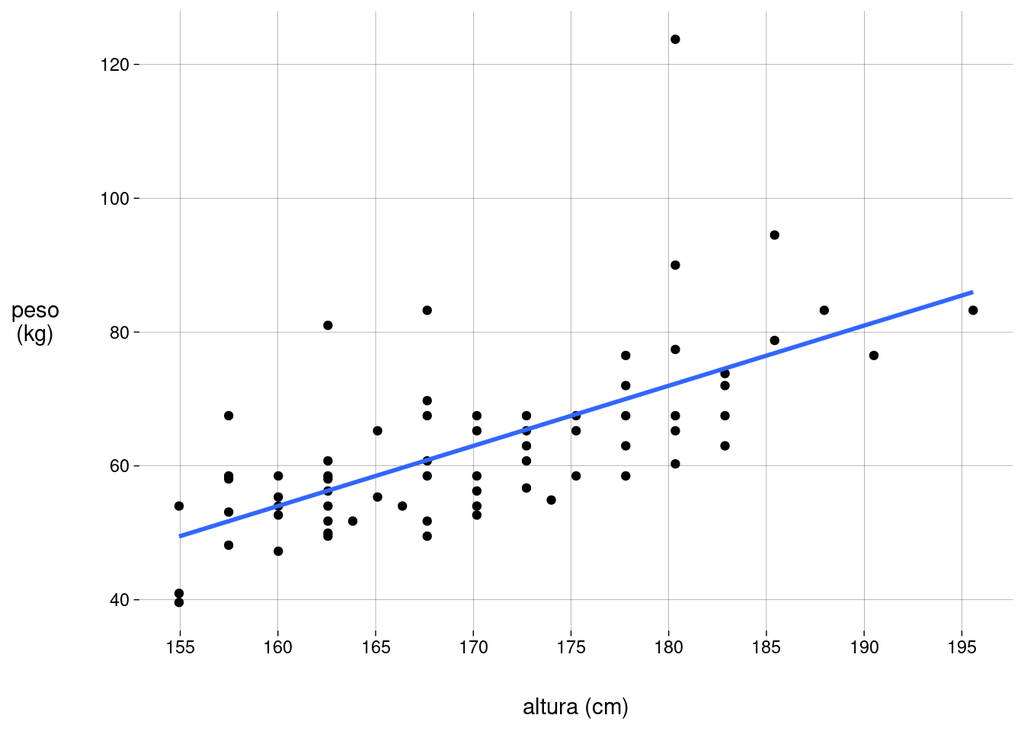

- Os resíduos mostram se o modelo é adequado.
  1. Devemos verificar se os resíduos seguem uma distribuição normal.

     Usando um histograma:

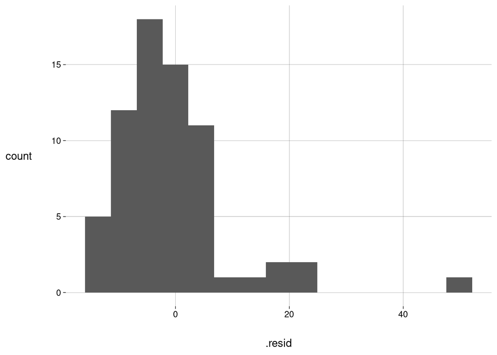

     ```r
     dados_aumentados %>%
       ggplot(aes(.resid)) +
         geom_histogram(bins = 15)
     ```

     Ou usando um gráfico quantil-quantil:

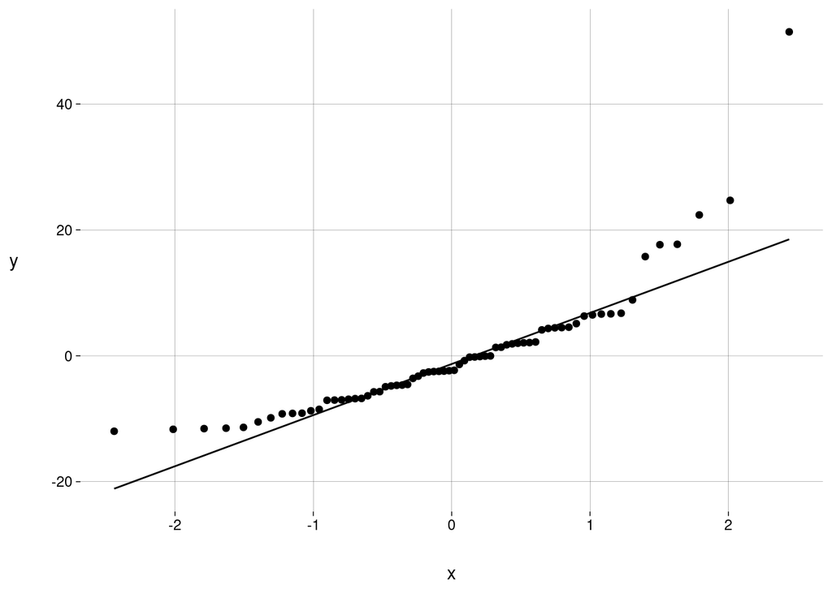

     ```r
     dados_aumentados %>%
       ggplot(aes(sample = .resid)) +
         geom_qq() +
         geom_qq_line()
     ```

     Ou fazendo um teste estatístico de normalidade:

     ```r
     dados_aumentados %>%
       pull(.resid) %>%
       shapiro.test()
     ```

     ```
     ##
     ##     Shapiro-Wilk normality test
     ##
     ## data:  .
     ## W = 0,8076, p-value = 0,00000005328
     ```

     Este resultado diz que não devemos considerar estes resíduos como sendo normais. Os resíduos à direita atrapalham muito. Se ignorarmos todos os resíduos maiores que $10$kg, o teste retorna um resultado mais compatível com a normalidade (mas não muito):

     ```r
     dados_aumentados %>%
       filter(.resid < 10) %>%
       pull(.resid) %>%
       shapiro.test()
     ```

     ```
     ##
     ##     Shapiro-Wilk normality test
     ##
     ## data:  .
     ## W = 0,96643, p-value = 0,08763
     ```

  2. Devemos verificar se os resíduos não dependem dos valores estimados.

     A idéia é que o *scatterplot* dos resíduos pelos valores estimados não deve apresentar nenhum padrão. A nuvem de pontos deve se distribuir de forma aparentemente aleatória em torno da reta horizontal $y = 0$ (a média dos resíduos), sem *outliers* e sem alterações significativas da variância.

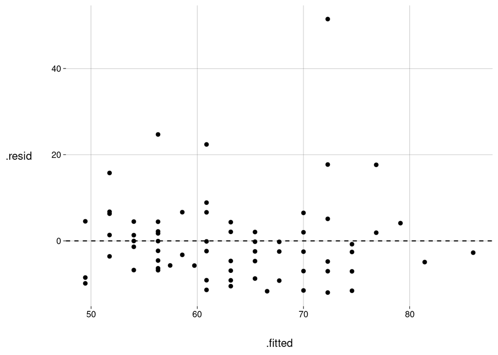

     ```r
     dados_aumentados %>%
       ggplot(aes(.fitted, .resid)) +
         geom_point() +
         geom_hline(yintercept = 0, linetype = 'dashed')
     ```

- O pacote `gglm` (http://graysonwhite.com/gglm/) tem `stat`s para estas verificações:

  ```r
  library(gglm)
  ```

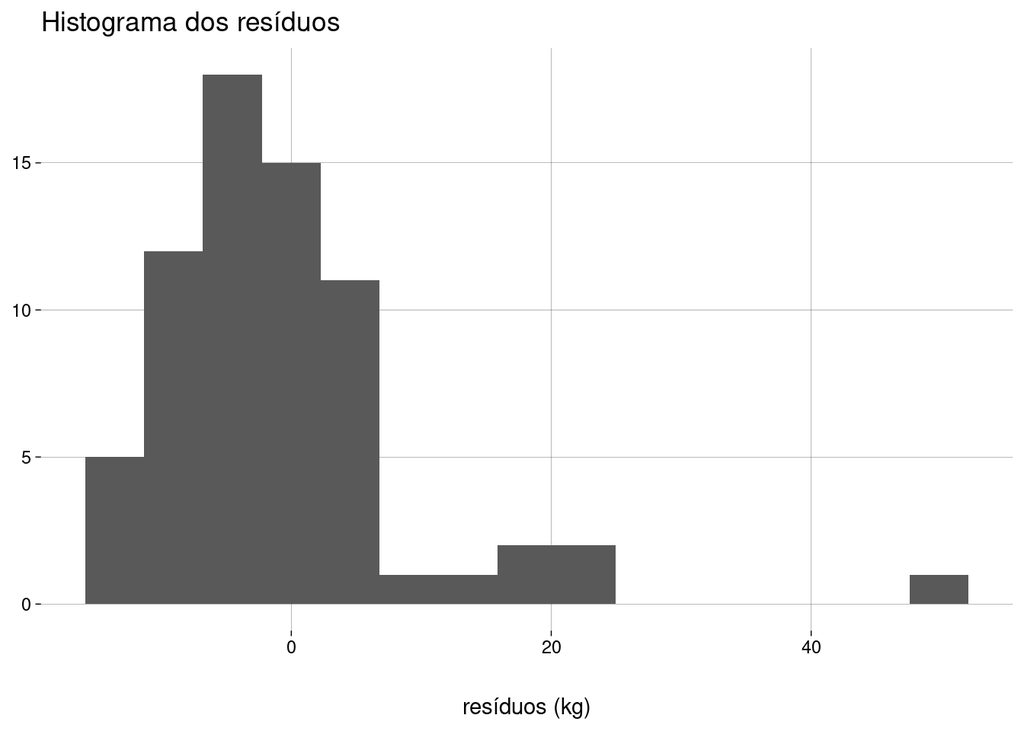

  ```r
  dados_aumentados %>%
    ggplot() +
      stat_resid_hist(bins = 15) +
      labs(
        x = 'resíduos (kg)',
        y = NULL,
        title = 'Histograma dos resíduos'
      )
  ```

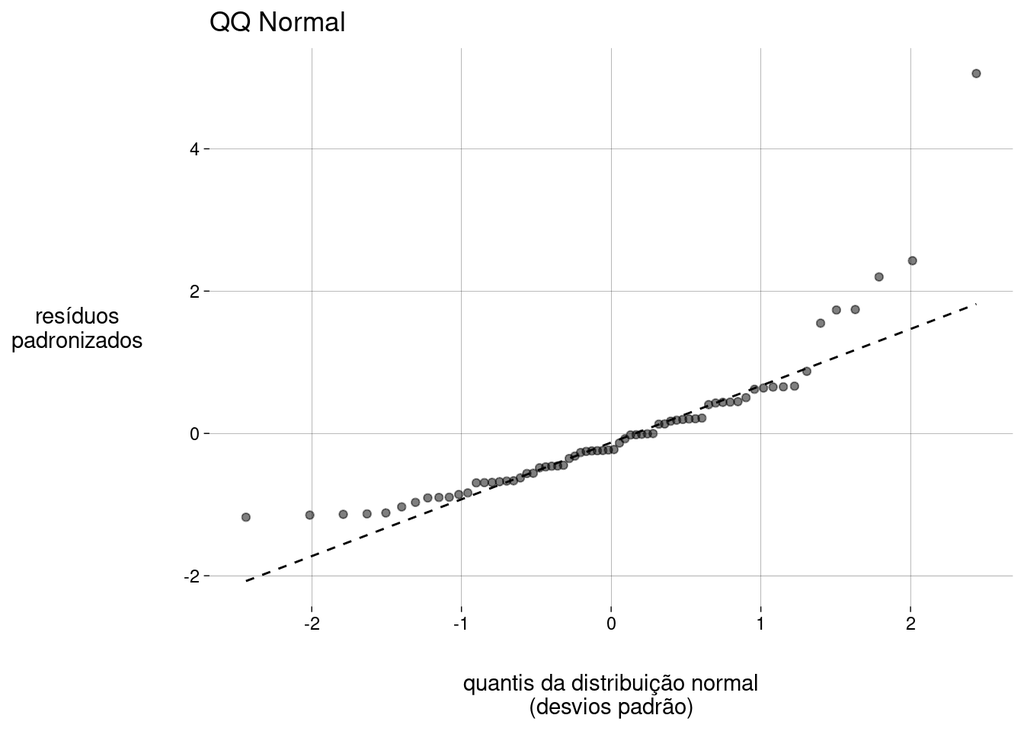

  ```r
  dados_aumentados %>%
    ggplot() +
      stat_normal_qq() +
      labs(
        x = 'quantis da distribuição normal\n(desvios padrão)',
        y = 'resíduos\npadronizados',
        title = 'QQ Normal'
      )
  ```

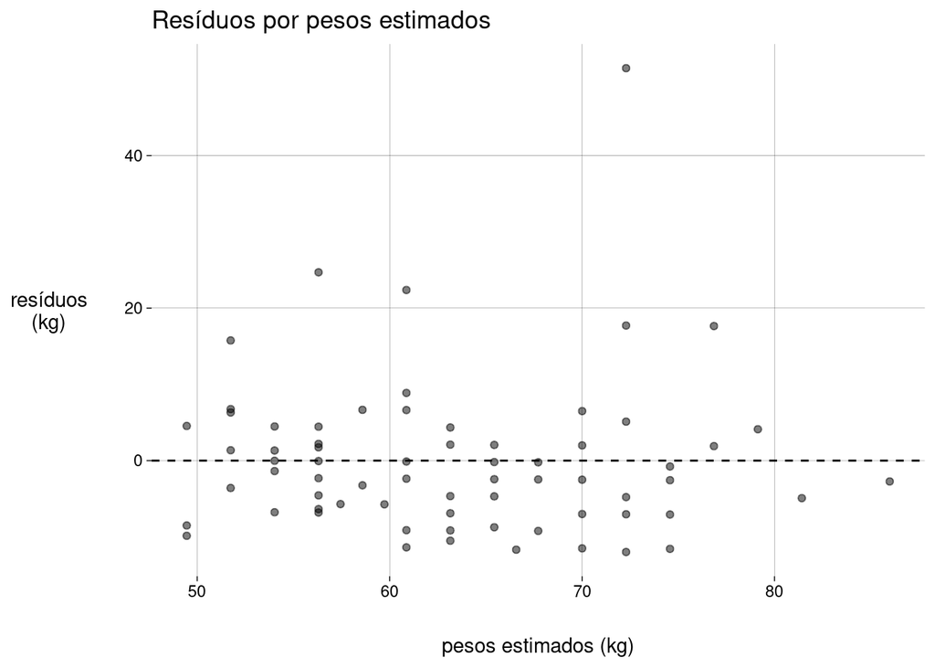

  ```r
  dados_aumentados %>%
    ggplot() +
      stat_fitted_resid() +
      labs(
        y = 'resíduos\n(kg)',
        x = 'pesos estimados (kg)',
        title = 'Resíduos por pesos estimados'
      )
  ```

- Se você não se importar com a feiúra dos gráficos do R base, pode usar a função `plot`:

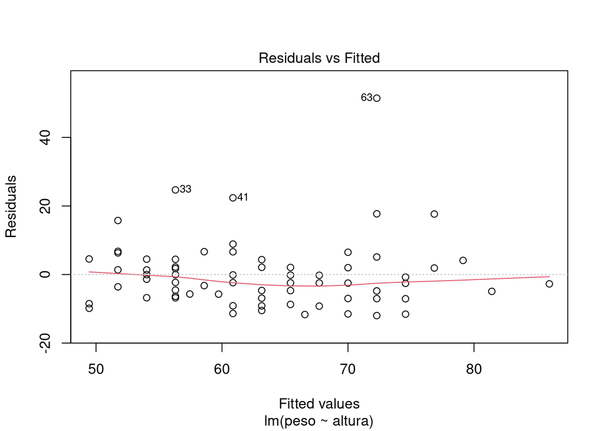

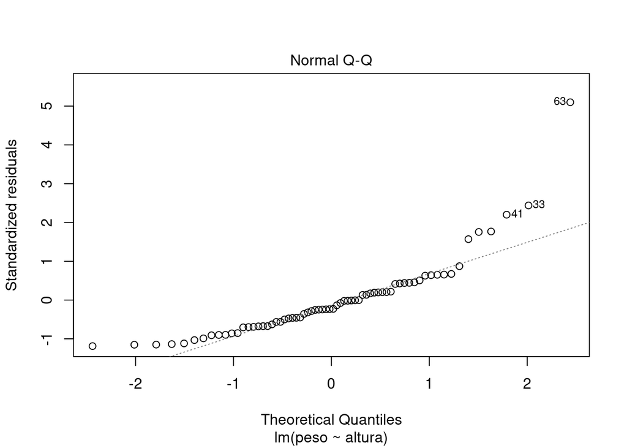

  ```r
  plot(modelo, c(1, 2))
  ```

- As observações com os maiores resíduos, $3$ delas marcadas com os números nos gráficos, são

  ```r
  dados_aumentados %>%
    slice_max(.resid, n = 6) %>%
    select(altura, peso, .fitted, .resid)
  ```

  | altura | peso | .fitted | .resid |
  | --- | --- | --- | --- |
  | 180,34 | 123,75 | 72,28573 | 51,46427 |
  | 162,56 | 81,00 | 56,30488 | 24,69512 |
  | 167,64 | 83,25 | 60,87084 | 22,37916 |
  | 180,34 | 90,00 | 72,28573 | 17,71427 |
  | 185,42 | 94,50 | 76,85168 | 17,64832 |
  | 157,48 | 67,50 | 51,73893 | 15,76107 |

## 4.1 Como os resíduos *não* devem ser

- A distribuição dos resíduos não deve se afastar da normal:

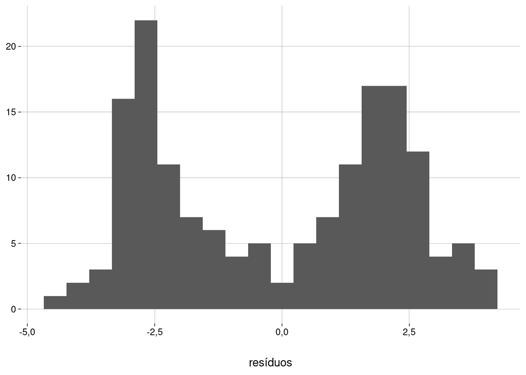

- O *scatterplot* não deve ter padrões visíveis:

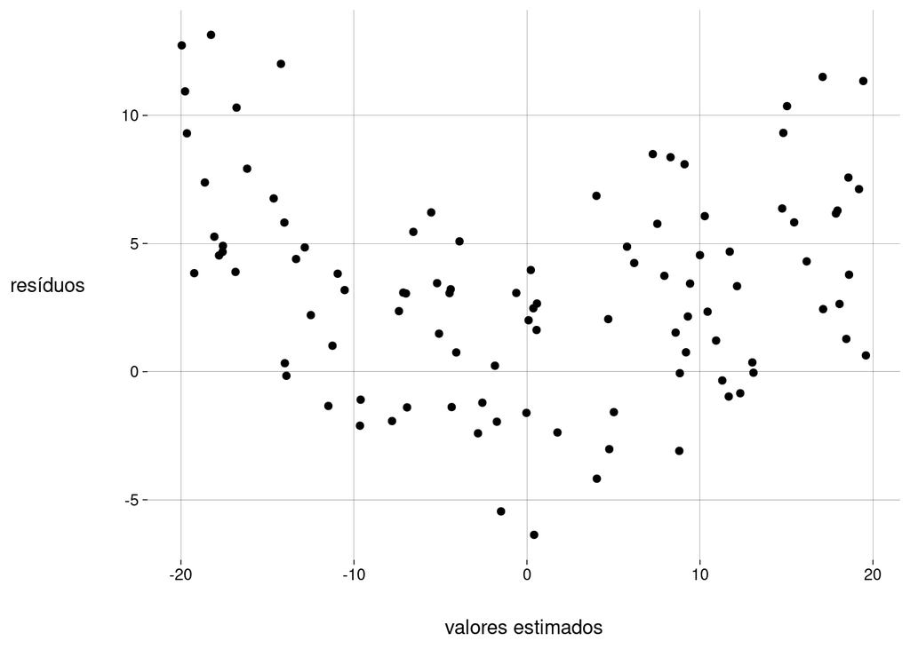

- No *scatterplot*, os resíduos não devem ter variabilidade diferente, dependendo do valor estimado:

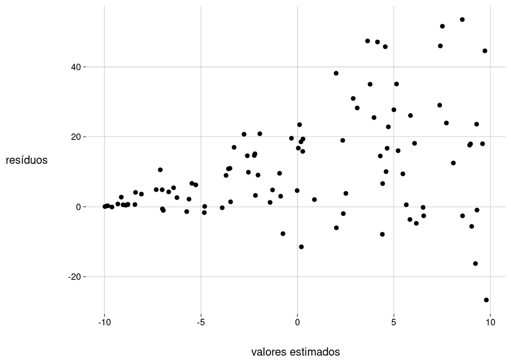

# 5 Condições para usar regressão linear

- As duas variáveis devem ser quantitativas.
- Como a equação da reta de regressão usa a correlação linear, devemos verificar que este é o tipo de correlação entre as duas variáveis. Um *scatterplot* é uma boa maneira de visualizar isto.
- Não deve haver *outliers* extremos.
- Uma vez definida a reta de regressão, devemos examinar os resíduos. No *scatterplot* de resíduos pelos valores estimados, a nuvem de pontos deve estar espalhada em torno da reta $y = 0$, sem padrões óbvios, sem curvatura, sem alterações na variância à medida que percorremos a reta horizontal..

# 6 Exemplo: furacões

- A pressão do ar no centro de um furacão está relacionada com a velocidade máxima dos ventos.
- Vamos usar o seguinte conjunto de dados para contruir um modelo linear:

  ```r
  furacoes <- hurricNamed %>%
    as_tibble() %>%
    transmute(
      nome = Name,
      ano = Year,
      velocidade = LF.WindsMPH * 1.8,      # convertido para km/h
      pressao = LF.PressureMB              # em mbar
    )

  furacoes
  ```

  | nome | ano | velocidade | pressao |
  | --- | --- | --- | --- |
  | Easy | 1950 | 216 | 958 |
  | King | 1950 | 234 | 955 |
  | Able | 1952 | 153 | 985 |
  | Barbara | 1953 | 153 | 987 |
  | Florence | 1953 | 153 | 985 |
  | Carol | 1954 | 216 | 960 |
  | Edna | 1954 | 216 | 954 |
  | Hazel | 1954 | 261 | 938 |
  | Connie | 1955 | 216 | 962 |
  | Diane | 1955 | 153 | 987 |

  [output cut: 84 more lines]

## 6.1 Examinar o *scatterplot*

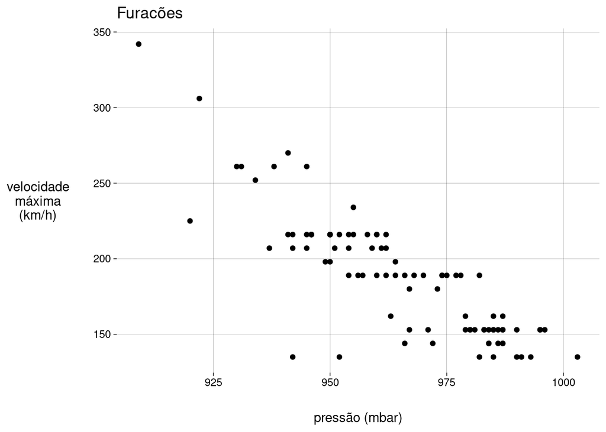

```r
grafico <- furacoes %>%
  ggplot(aes(pressao, velocidade)) +
    geom_point() +
    labs(
      x = 'pressão (mbar)',
      y = 'velocidade\nmáxima\n(km/h)',
      title = 'Furacões'
    )

grafico
```

- As duas variáveis são quantitativas.
- A relação entre velocidade e pressão é aproximadamente linear.
- Quanto maior a pressão, menor a velocidade. A correlação é negativa.
- Há $3$ potenciais *outliers*, mas vamos prosseguir mesmo assim.
- Os pontos parecem estar dispostos em filas horizontais. Isto é causado pela (falta de) precisão das velocidades, que são valores inteiros no conjunto de dados.

## 6.2 Construir o modelo

```r
modelo <- lm(velocidade ~ pressao, data = furacoes)
summary(modelo)
```

```
##
## Call:
## lm(formula = velocidade ~ pressao, data = furacoes)
##
## Residuals:
##     Min      1Q  Median      3Q     Max
## -92,201  -8,841   0,326  12,777  57,604
##
## Coefficients:
##             Estimate Std. Error t value            Pr(>|t|)
## (Intercept) 1859,852    109,928   16,92 <0,0000000000000002 ***
## pressao       -1,733      0,114  -15,21 <0,0000000000000002 ***
## ---
## Signif. codes:  0 '***' 0,001 '**' 0,01 '*' 0,05 '.' 0,1 ' ' 1
##
## Residual standard error: 21,7 on 92 degrees of freedom
## Multiple R-squared:  0,7154, Adjusted R-squared:  0,7123
## F-statistic: 231,3 on 1 and 92 DF,  p-value: < 0,00000000000000022
```

- A equação é

  $$\widehat{\text{velocidade}} = 1.859{,}85 + (-1{,}73) \cdot \text{pressão}$$
- A cada mbar de aumento na pressão está associada uma mudança de $-1{,}73$km/h na velocidade.
- Gráfico:

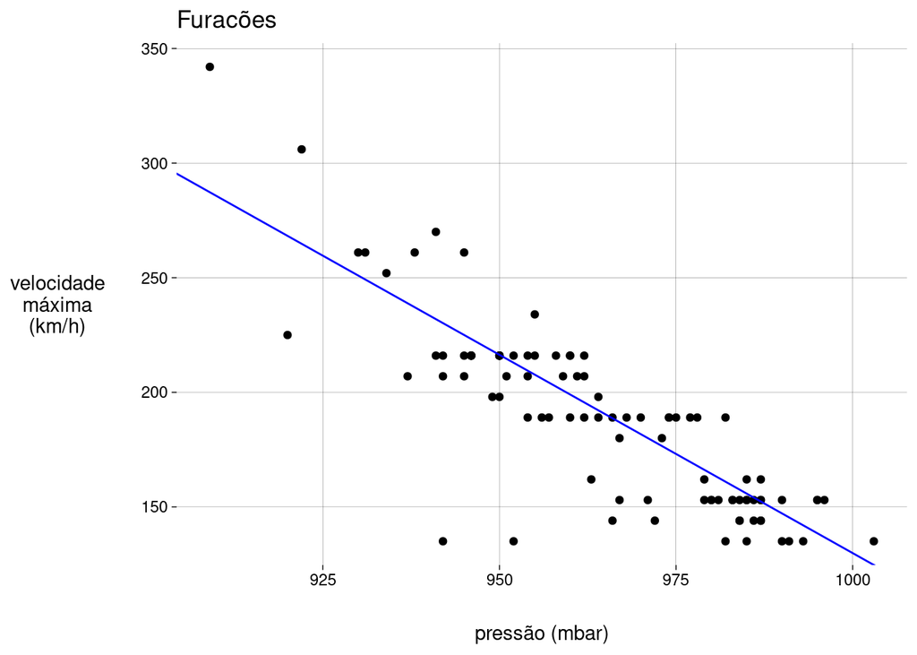

## 6.3 Examinar os resíduos

- Histograma dos resíduos:

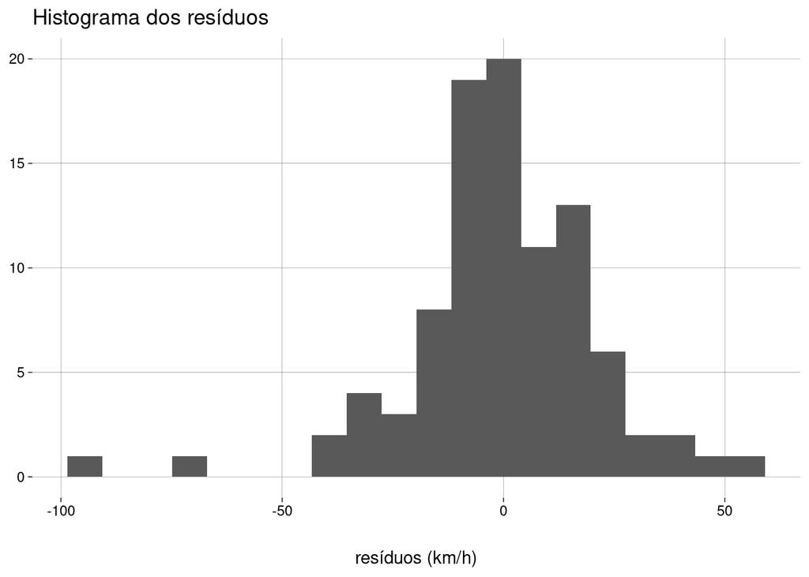

  ```r
  modelo %>%
    ggplot() +
      stat_resid_hist(bins = 20) +
      labs(
        x = 'resíduos (km/h)',
        y = NULL,
        title = 'Histograma dos resíduos'
      )
  ```

- Ignorando os *outliers* à esquerda, a distribuição dos resíduos é aproximadamente normal.
- Incluindo todos os resíduos, o teste de normalidade é horrível:

  ```r
  dados_aumentados <- augment_columns(modelo, data = furacoes)

  dados_aumentados %>%
    pull(.resid) %>%
    shapiro.test()
  ```

  ```
  ##
  ##  Shapiro-Wilk normality test
  ##
  ## data:  .
  ## W = 0,92879, p-value = 0,00007165
  ```

- Eliminando os resíduos extremos à esquerda, o resultado é bom:

  ```r
  dados_aumentados %>%
    filter(.resid > -50) %>%
    pull(.resid) %>%
    shapiro.test()
  ```

  ```
  ##
  ##  Shapiro-Wilk normality test
  ##
  ## data:  .
  ## W = 0,98682, p-value = 0,487
  ```

- Gráfico QQ dos resíduos:

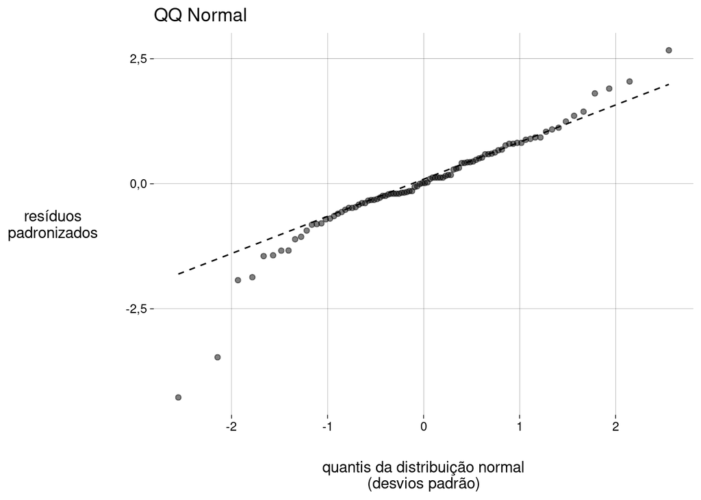

  ```r
  modelo %>%
    ggplot() +
      stat_normal_qq() +
      labs(
        x = 'quantis da distribuição normal\n(desvios padrão)',
        y = 'resíduos\npadronizados',
        title = 'QQ Normal'
      )
  ```

- Resíduos por valores estimados:

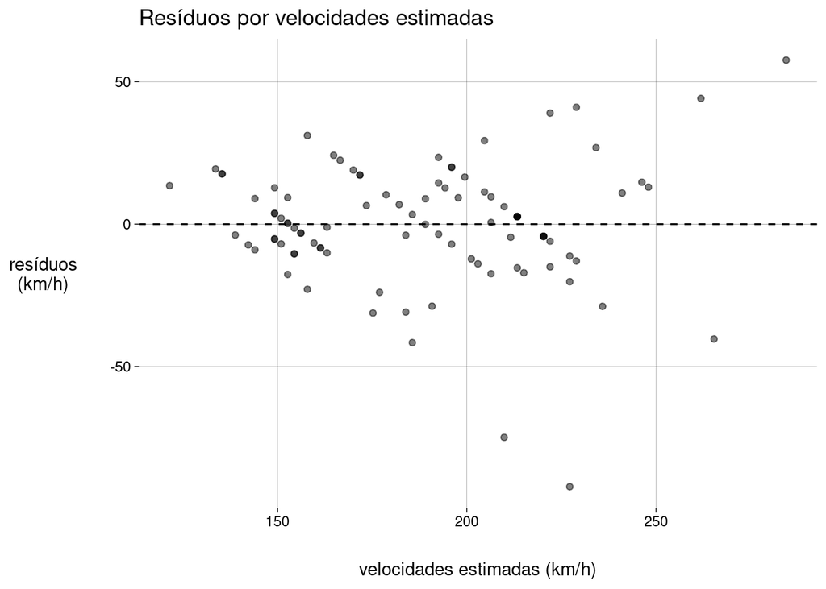

  ```r
  modelo %>%
    ggplot() +
      stat_fitted_resid() +
      labs(
        y = 'resíduos\n(km/h)',
        x = 'velocidades estimadas (km/h)',
        title = 'Resíduos por velocidades estimadas'
      )
  ```

- As filas de pontos aparecem porque as velocidades são valores inteiros no conjunto de dados.
- Quase todos os resíduos têm valor absoluto menor que $50$km/h.
- Vamos ver as exceções:

  ```r
  dados_aumentados %>%
    filter(abs(.resid) > 50) %>%
    select(nome, ano, pressao, velocidade, .fitted, .resid)
  ```

  | nome | ano | pressao | velocidade | .fitted | .resid |
  | --- | --- | --- | --- | --- | --- |
  | Camille | 1969 | 909 | 342 | 284,3955 | 57,60448 |
  | Irene | 2011 | 952 | 135 | 209,8690 | -74,86897 |
  | Sandy | 2012 | 942 | 135 | 227,2007 | -92,20073 |

- A variância dos resíduos é menor para velocidades estimadas menores (no lado esquerdo do gráfico). À medida que a velocidade estimada aumenta, a variância aumenta também.
- Esta variância não-constante afeta os resultados dos testes estatísticos sobre os coeficientes, um assunto que vamos abordar depois.

## 6.4 Exercícios

- O que significa o intercepto de $1.859{,}85$km/h?
- Qual a previsão do modelo para a velocidade máxima de um furacão com pressão de $925$mbar?
- Na *tibble* `furacoes`, crie uma coluna `faixa` com os seguintes valores:

  $$\text{faixa} =
  \begin{cases}
  \text{A} &\text{ se velocidade estimada } < 150 \\
  \text{B} &\text{ se } 150 \leq \text{velocidade estimada } < 200 \\
  \text{C} &\text{ se velocidade estimada } \geq 200
  \end{cases}$$

  Usando `group_by` e `summarize`, calcule a variância das velocidades estimadas de cada faixa. É verdade que, à medida que a velocidade estimada aumenta, a variância aumenta também?

# 7 Exemplo: a lei de Moore

- A [lei de Moore](https://pt.wikipedia.org/wiki/Lei_de_Moore) estima que, a cada dois anos, o número de transistores em um circuito integrado dobra.
- Vamos usar o *dataset* em https://raw.githubusercontent.com/egarpor/handy/master/datasets/cpus.txt, salvo localmente.

  ```r
  moore <- read_csv2(
    'data/cpus.csv'
  ) %>%
    select(
      processador = Processor,
      transistores = 'Transistor count',
      ano = 'Date of introduction'
    )

  moore
  ```

  | processador | transistores | ano |
  | --- | --- | --- |
  | TMS 1000 | 8000 | 1971 |
  | Intel 4004 | 2300 | 1971 |
  | Intel 8008 | 3500 | 1972 |
  | MOS Technology 6502 | 3510 | 1975 |
  | Motorola 6800 | 4100 | 1974 |
  | Intel 8080 | 4500 | 1974 |
  | RCA 1802 | 5000 | 1974 |
  | Intel 8085 | 6500 | 1976 |
  | Zilog Z80 | 8500 | 1976 |
  | Motorola 6809 | 9000 | 1978 |

  [output cut: 92 more lines]

- Usando regressão linear, podemos confirmar a lei de Moore para estes dados?

## 7.1 Examinar o *scatterplot*

```r
library(scales)
```

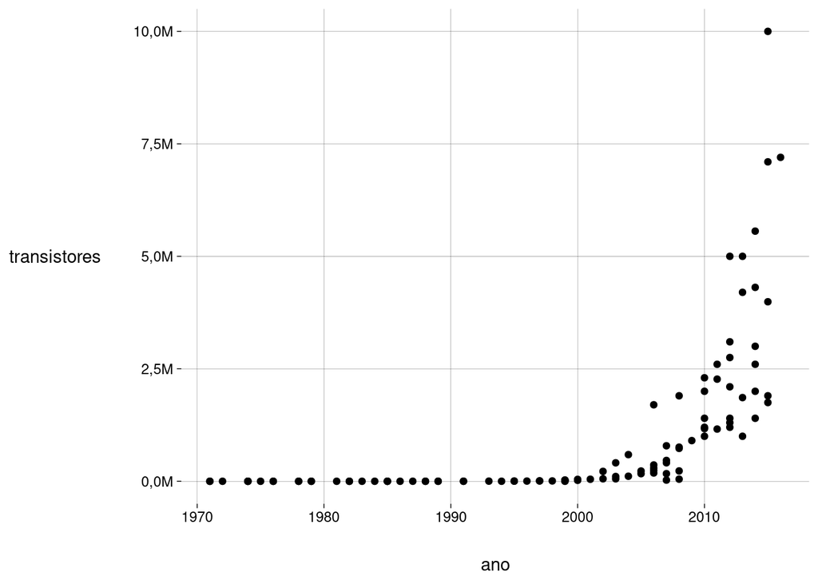

```r
moore %>%
  ggplot(aes(ano, transistores)) +
    geom_point() +
    scale_y_continuous(
      labels = label_number(scale = 1e-9, decimal.mark = ',', suffix = 'M')
    )
```

- Como já era de se esperar (pelo próprio enunciado da lei!) a relação não é linear, mas sim exponencial.
- Então, vamos usar o logaritmo do número de transistores:

  ```r
  moore <- moore %>%
    mutate(ltransistores = log10(transistores))
  ```

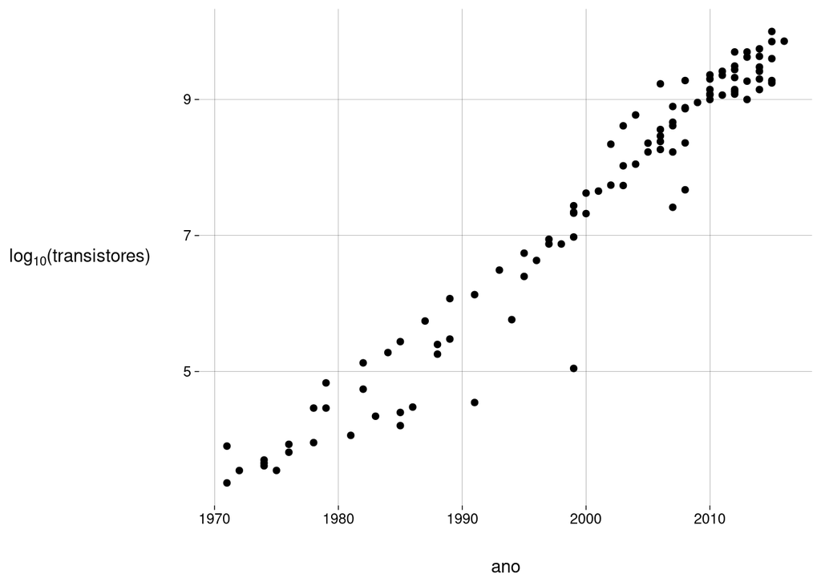

  ```r
  grafico <- moore %>%
    ggplot(aes(ano, ltransistores)) +
      geom_point() +
      labs(
        y = TeX('log_{10}(transistores)')
      )

  grafico
  ```

- Agora, sim. Bem melhor.

## 7.2 Construir o modelo

```r
modelo <- lm(ltransistores ~ ano, data = moore)
```

```r
summary(modelo)
```

```
##
## Call:
## lm(formula = ltransistores ~ ano, data = moore)
##
## Residuals:
##      Min       1Q   Median       3Q      Max
## -2,22795 -0,14242  0,07515  0,22671  0,89568
##
## Coefficients:
##                Estimate  Std. Error t value            Pr(>|t|)
## (Intercept) -295,858219    6,843549  -43,23 <0,0000000000000002 ***
## ano            0,151642    0,003422   44,31 <0,0000000000000002 ***
## ---
## Signif. codes:  0 '***' 0,001 '**' 0,01 '*' 0,05 '.' 0,1 ' ' 1
##
## Residual standard error: 0,4556 on 100 degrees of freedom
## Multiple R-squared:  0,9515, Adjusted R-squared:  0,9511
## F-statistic:  1963 on 1 and 100 DF,  p-value: < 0,00000000000000022
```

- A equação é

  $$\widehat{\text{log(transistores)}} = -295{,}86 + 0{,}15 \cdot \text{ano}$$
- A equação diz que, a cada $2$ anos, o logaritmo do número de transistores (na base $10$) aumenta de $0{,}30$.
- Chamando de $t(n)$ o número de transistores no ano $n$, a equação diz que:

  $$\begin{align*}
  \log t(n + 2) = \log t(n) + 0{,}30
  & \implies
  t(n + 2) = t(n) \cdot 10^{0{,}30}
  & \text{(elevando }10\text{ a cada lado)} \\
  & \implies
  t(n + 2) = 2{,}01 \cdot t(n)
  \end{align*}$$
- Isto corresponde ao que a lei de Moore diz: a cada $2$ anos, o número de transistores aproximadamente dobra.
- O gráfico fica:

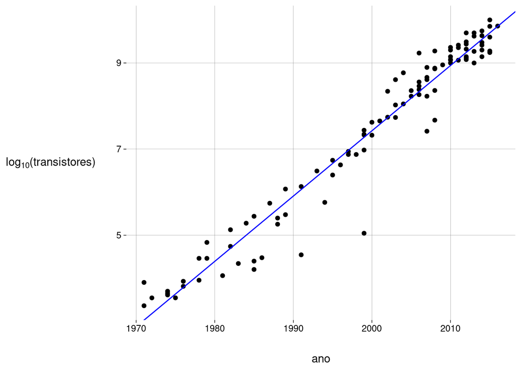

## 7.3 Examinar os resíduos

- Histograma dos resíduos:

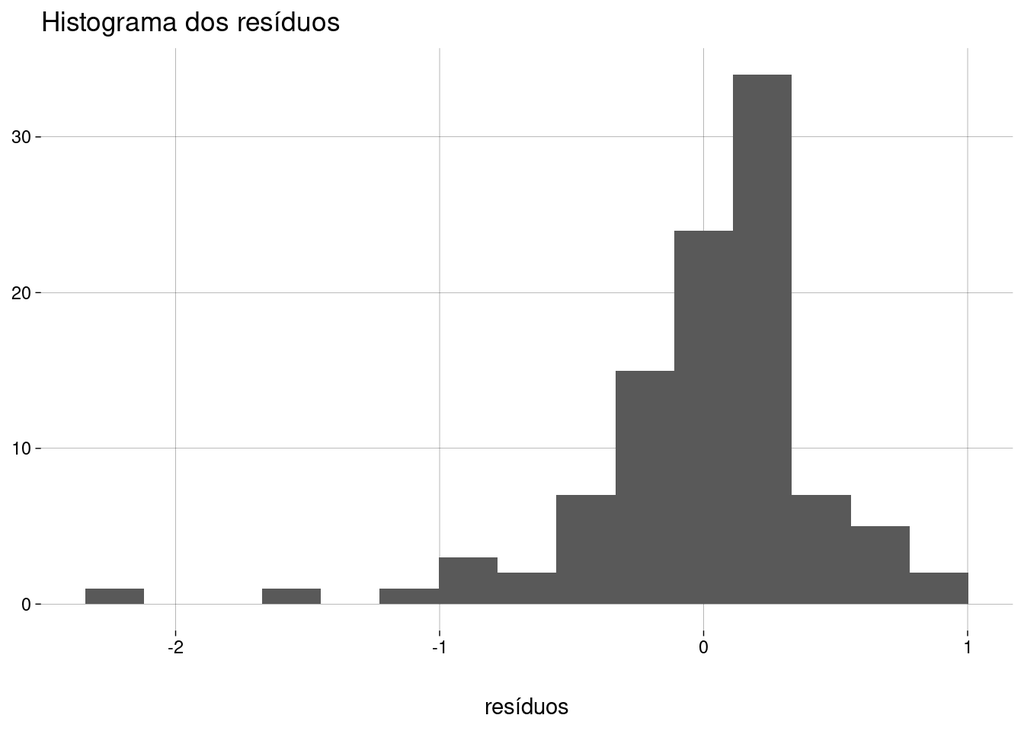

  ```r
  modelo %>%
    ggplot() +
      stat_resid_hist(bins = 15) +
      labs(
        x = 'resíduos',
        y = NULL,
        title = 'Histograma dos resíduos'
      )
  ```

- Ignorando os *outliers* à esquerda, a distribuição dos resíduos é aproximadamente normal.
- Um resíduo de $-1$ no logaritmo (na base $10$) do número de transistores equivale a $\frac{1}{10}$ do número de transistores estimado pela regressão.
- Um resíduo de $-2$ no logaritmo (na base $10$) do número de transistores equivale a $\frac{1}{100}$ do número de transistores estimado pela regressão.
- Teste de normalidade com todos os resíduos:

  ```r
  dados_aumentados <- augment_columns(modelo, data = moore)

  dados_aumentados %>%
    pull(.resid) %>%
    shapiro.test()
  ```

  ```
  ##
  ##  Shapiro-Wilk normality test
  ##
  ## data:  .
  ## W = 0,87608, p-value = 0,0000000991
  ```

- Sem os *outliers*:

  ```r
  dados_aumentados %>%
    filter(.resid > -.5) %>%
    pull(.resid) %>%
    shapiro.test()
  ```

  ```
  ##
  ##  Shapiro-Wilk normality test
  ##
  ## data:  .
  ## W = 0,97828, p-value = 0,1236
  ```

- Gráfico QQ dos resíduos:

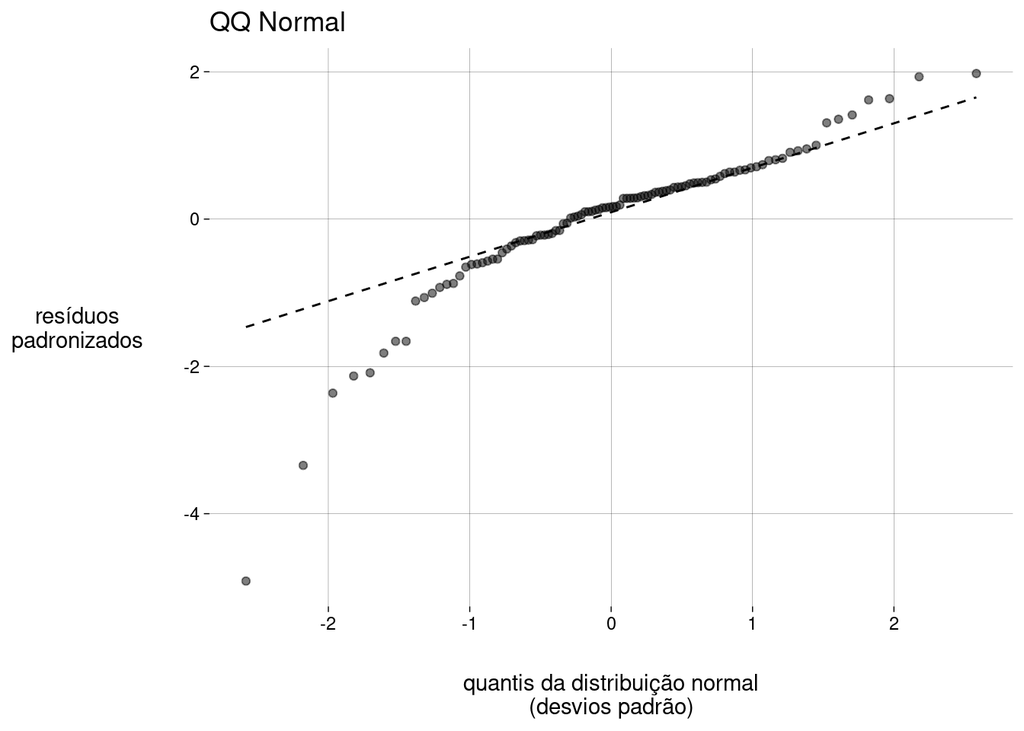

  ```r
  modelo %>%
    ggplot() +
      stat_normal_qq() +
      labs(
        x = 'quantis da distribuição normal\n(desvios padrão)',
        y = 'resíduos\npadronizados',
        title = 'QQ Normal'
      )
  ```

- Aqui também ficam nítidos os *outliers* à esquerda.
- Resíduos por valores estimados:

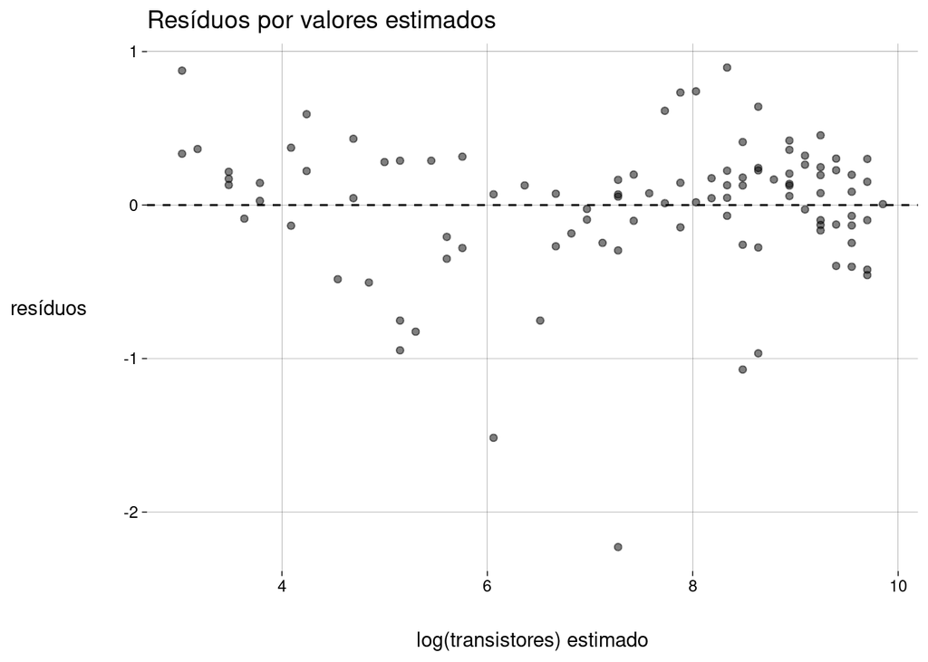

  ```r
  modelo %>%
    ggplot() +
      stat_fitted_resid() +
      labs(
        y = 'resíduos',
        x = 'log(transistores) estimado',
        title = 'Resíduos por valores estimados'
      )
  ```

- De novo, os *outliers* são óbvios. Vamos listar as CPUs com resíduo menor que $-0{,}5$:

  ```r
  dados_aumentados %>%
    filter(.resid < -.5) %>%
    select(processador, transistores, ano, ltransistores, .fitted, .resid) %>%
    arrange(.resid)
  ```

  | processador | transistores | ano | ltransistores | .fitted | .resid |
  | --- | --- | --- | --- | --- | --- |
  | ARM 9TDMI | 111000 | 1999 | 5,045323 | 7,273277 | -2,2279540 |
  | ARM 6 | 35000 | 1991 | 4,544068 | 6,060144 | -1,5160763 |
  | ARM Cortex-A9 | 26000000 | 2007 | 7,414973 | 8,486409 | -1,0714361 |
  | Atom | 47000000 | 2008 | 7,672098 | 8,638051 | -0,9659532 |
  | Novix NC4016 | 16000 | 1985 | 4,204120 | 5,150295 | -0,9461750 |
  | ARM 2 | 30000 | 1986 | 4,477121 | 5,301937 | -0,8248153 |
  | ARM700 | 578977 | 1994 | 5,762661 | 6,515069 | -0,7524078 |
  | ARM 1 | 25000 | 1985 | 4,397940 | 5,150295 | -0,7523550 |
  | WDC 65C816 | 22000 | 1983 | 4,342423 | 4,847012 | -0,5045892 |

- Os resíduos parecem não ter variância constante.
- Além disso, parece haver uma certa curvatura na nuvem de pontos.

## 7.4 Exercícios

- Faça uma pesquisa *online* e tente descobrir se há algum motivo específico para a maioria dos *outliers* ser de processadores ARM.
- Faça uma pesquisa *online* sobre processadores lançados nos anos de $2017$, $2018$, $2019$, $2020$ e $2021$ (no mínimo um processador de cada ano); compare as quantidades de transistores dos processadores que você achou com as quantidades de transistores previstas para eles pelo modelo linear.
- A lei de Moore vale para estas GPUs?

  ```r
  gpus <-
    read_csv2('data/gpus.csv') %>%
    select(
      processador = Processor,
      transistores = 'Transistor count',
      ano = 'Date of introduction',
      fabricante = Manufacturer
    )

  gpus
  ```

  | processador | transistores | ano | fabricante |
  | --- | --- | --- | --- |
  | NV3 | 3500000 | 1997 | NVIDIA |
  | Rage 128 | 8000000 | 1999 | AMD |
  | NV5 | 15000000 | 1999 | Nvidia |
  | NV10 | 23000000 | 1999 | Nvidia |
  | NV11 | 20000000 | 2000 | Nvidia |
  | NV15 | 25000000 | 2000 | Nvidia |
  | R100 | 30000000 | 2000 | AMD |
  | NV20 | 57000000 | 2001 | Nvidia |
  | R200 | 60000000 | 2001 | AMD |
  | NV25 | 63000000 | 2002 | Nvidia |

  [output cut: 25 more lines]